# Practical Machine Learning Project

April, 25 2015

# Weight lifting exercises Data Analysis Report

## Introduction

Using devices such as Jawbone Up, Nike FuelBand, and Fitbit it is now possible to collect a large amount of data about personal activity relatively inexpensively. These type of devices are part of the quantified self movement - a group of enthusiasts who take measurements about themselves regularly to improve their health, to find patterns in their behavior, or because they are tech geeks. One thing that people regularly do is quantify how much of a particular activity they do, but they rarely quantify how well they do it.

In this project, we use data from accelerometers on the belt, forearm, arm, and dumbell of 6 participants. They were asked to perform barbell lifts correctly and incorrectly in 5 different ways.

Our objective is to predict the manner in which they did the exercise.

More information is available from the website here: http://groupware.les.inf.puc-rio.br/har (see the section on the Weight Lifting Exercise Dataset).

## Data

The training data for this project are available here: https://d396qusza40orc.cloudfront.net/predmachlearn/pml-training.csv

The test data are available here: https://d396qusza40orc.cloudfront.net/predmachlearn/pml-testing.csv

## Basic Settings

We will load all the libraries to be used along this report.

```r
library(caret)
library(randomForest)
```

```r
library(rpart)
library(rpart.plot)
library(corrplot)
```

## Reading the Data

The data set files (train and test) to be used in our analysis will be downloaded from the above mentioned location. It will only happen on the first execution.

```r
train_file <- "./data/pml-training.csv"
test_file  <-"./data/pml-testing.csv"

# only download if required
if(file.exists( train_file ) == 0)
{
    train_url <- "https://d396qusza40orc.cloudfront.net/predmachlearn/pml-training.csv"
    download.file(fileUrl , destfile=train_url , method="curl")
}
if(file.exists( test_file ) == 0)
{
    test_url <- "https://d396qusza40orc.cloudfront.net/predmachlearn/pml-testing.csv"
    download.file(fileUrl , destfile=test_url , method="curl")
}

# reading the train data file
original_train_data <- read.csv(train_file, na.strings=c("", "NA"))
dim(original_train_data)
```

```
## [1] 19622   160
```

```r
# reading the test data file
original_test_data  <- read.csv(test_file, na.strings=c("", "NA"))
dim(original_test_data)
```

```
## [1]  20 160
```

The original training data set contains **19622** rows (or observations) and **160** columns (or variables).

## Pre-processing the Data

We will clean the data sets removing the observations and variables not required in our analysis, as well as the missing values where imputing is not an option.

```r
train_data <- original_train_data[, colSums(is.na(original_train_data)) == 0]
test_data  <- original_test_data[, colSums(is.na(original_test_data)) == 0]

# nullifying the columns to be removed
colnames_to_remove <- c("X", "user_name", "raw_timestamp_part_1",
                    "raw_timestamp_part_2", "cvtd_timestamp", "num_window")
for (col in colnames_to_remove) {
    train_data[, col] <- NULL
}

# remove the nullified columns and the ones with unique value (zero variance predictors)
nzv <- nearZeroVar(train_data)
train_data <- train_data[-nzv]
test_data  <- test_data[-nzv]
```

The final structure set is as per below.

```r
names(train_data)
```

```
##  [1] "roll_belt"            "pitch_belt"           "yaw_belt"
##  [4] "total_accel_belt"     "gyros_belt_x"         "gyros_belt_y"
##  [7] "gyros_belt_z"         "accel_belt_x"         "accel_belt_y"
## [10] "accel_belt_z"         "magnet_belt_x"        "magnet_belt_y"
## [13] "magnet_belt_z"        "roll_arm"             "pitch_arm"
## [16] "yaw_arm"              "total_accel_arm"      "gyros_arm_x"
## [19] "gyros_arm_y"          "gyros_arm_z"          "accel_arm_x"
## [22] "accel_arm_y"          "accel_arm_z"          "magnet_arm_x"
## [25] "magnet_arm_y"         "magnet_arm_z"         "roll_dumbbell"
## [28] "pitch_dumbbell"       "yaw_dumbbell"         "total_accel_dumbbell"
## [31] "gyros_dumbbell_x"     "gyros_dumbbell_y"     "gyros_dumbbell_z"
## [34] "accel_dumbbell_x"     "accel_dumbbell_y"     "accel_dumbbell_z"
## [37] "magnet_dumbbell_x"    "magnet_dumbbell_y"    "magnet_dumbbell_z"
## [40] "roll_forearm"         "pitch_forearm"        "yaw_forearm"
## [43] "total_accel_forearm"  "gyros_forearm_x"      "gyros_forearm_y"
## [46] "gyros_forearm_z"      "accel_forearm_x"      "accel_forearm_y"
## [49] "accel_forearm_z"      "magnet_forearm_x"     "magnet_forearm_y"
## [52] "magnet_forearm_z"     "classe"
```

## Data Modelling

```r
set.seed(224)
# slicing/partitioning the data set
inTrain <- createDataPartition(train_data$classe, p=0.70, list=F)
newtrain_data <- train_data[inTrain, ]
newtest_data <- train_data[-inTrain, ]
```

We will then use the *Random Forest* classifier to predict the action class. The accuracy of the model is to be measured using the *10-fold cross validation*.

```r
control_rf <- trainControl(method="cv", 10)
model_rf <- train(classe ~ . , data=newtrain_data
                  , method = "rf"
                  , trControl = control_rf
                  , ntree = 250)
model_rf
```

```
## Random Forest
##
## 13737 samples
##    52 predictor
##     5 classes: 'A', 'B', 'C', 'D', 'E'
##
## No pre-processing
## Resampling: Cross-Validated (10 fold)
##
## Summary of sample sizes: 12363, 12363, 12364, 12363, 12363, 12363, ...
##
## Resampling results across tuning parameters:
##
##   mtry  Accuracy   Kappa      Accuracy SD  Kappa SD
##    2    0.9925746  0.9906065  0.001365394  0.001728170
##   27    0.9922113  0.9901473  0.002000571  0.002530353
##   52    0.9827480  0.9781738  0.003879753  0.004905534
##
## Accuracy was used to select the optimal model using  the largest value.
## The final value used for the model was mtry = 2.
```

```r
predict_rf <- predict(model_rf, newtest_data)
conf_matrix <- confusionMatrix(newtest_data$classe, predict_rf)

mod_accuracy <- postResample(predict_rf, newtest_data$classe)
mod_accuracy
```

```
##  Accuracy     Kappa
## 0.9926933 0.9907568
```

```r
out_sample_error <- 1 - as.numeric(conf_matrix$overall[1])
out_sample_error
```

```
## [1] 0.007306712
```

So, the estimated *accuracy* of the model is 99.2693288% and the estimated *out-of-sample error* is 0.0073067.

The proposed model seems classifying well enough.

## Decision Tree Graph

We can see the Decision Tree as per below:

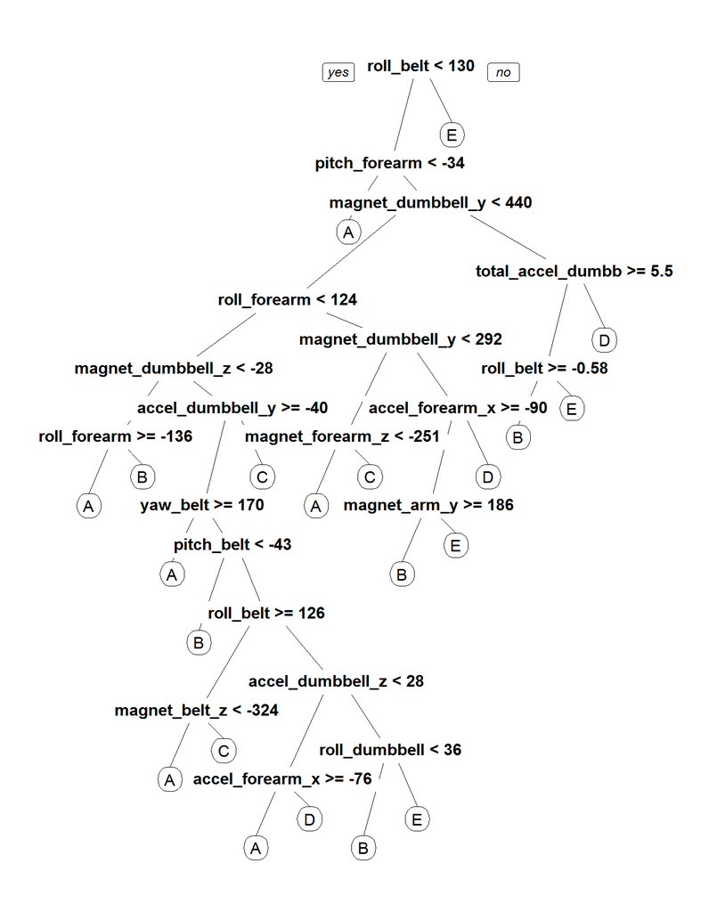

```r
tree_model <- rpart(classe ~ ., data=newtrain_data, method="class")
prp(tree_model)
```